# Project Presentation

Celine Onyemaechi

# Project Overview

## About the Data

- Behavioral data from Kalbe & Schwabe (2022)
- Investigates emotional experiences and their effect on memory
- Examined memory performance in participants exposed to conditioned and non-conditioned stimuli

## Experimental Design

- Initially neutral stimuli: images of animals and tools
- Categories
  - $CS+$: image category associated with aversive event
  - $CS-$: image category not associated with aversive event

# Data Manipulation

## Key Variables

- *study_id* : The number of the experiment
- *participant_id* : The ID number of the participant
- *condition* : The category of the item
  - CSm
  - CSp
- *phase* : The phase of the experiment during which the items were first presented
  - conditioning
  - post-conditioning
  - pre-conditioning
- *hit* : Hit rate
- *fa* : False alarm rate

## Data Processing

1. Import `.csv` files into R environment using `read_csv()`
2. Pool experiment datasets
   - Ensure each participant has a unique ID across the experiemnts
3. Compute “Corrected Recogniton” as a new variable
   - `CR = hit - fa`

## Data Visualization

**Goal**: Recreate *Figure 3* from Kalbe & Schwabe (2022)

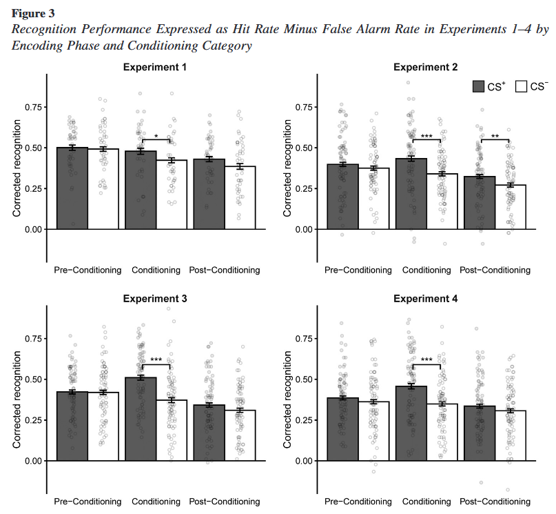

This is *Figure 3* from Kalbe & Schwabe (2022)

## Data Visualization

- Create multiple panel plot
  - You can use `facet_grid` or `facet_wrap` function from the `ggplot2` package
- Map the *phase* to the x-axis and *corrected recognition* to the y-axis
- Add individual data points over the bars
- Optional: add the p-values